# Reproducible Research - Personal Movement Tracking

24 February 2017

## Initial preparation

Ensure first that all additional packages are loaded for the exercise:

```r
if(!require(ggplot2)){
    install.packages("ggplot2")
    library(ggplot2)
}
if(!require(lattice)){
    install.packages("lattice")
    library(lattice)
}
```

## Loading and preprocessing the data

The data to be used in this project can be found [here](https://d396qusza40orc.cloudfront.net/repdata%2Fdata%2Factivity.zip) in compressed format. The code below downloads the data into the current working directory, unzips it and puts it into a dataframe for subsequent processing.

```r
download.file("https://d396qusza40orc.cloudfront.net/repdata%2Fdata%2Factivity.zip", "activity.zip", quiet = TRUE)
unzip("activity.zip", files = "activity.csv", overwrite = TRUE)
dfRawData <- read.csv("activity.csv")
```

## What is mean total number of steps taken per day?

1. Calculate the total number of steps taken per day.

To determine this, create a dataframe summarising the data by date, omitting missing values.

```r
dfStepsByDate <- aggregate(steps ~ date, data = dfRawData, sum, na.action = na.omit)
dfStepsByDate
```

```
##          date steps
## 1  2012-10-02   126
## 2  2012-10-03 11352
## 3  2012-10-04 12116
## 4  2012-10-05 13294
## 5  2012-10-06 15420
## 6  2012-10-07 11015
## 7  2012-10-09 12811
## 8  2012-10-10  9900
## 9  2012-10-11 10304
## 10 2012-10-12 17382
## 11 2012-10-13 12426
## 12 2012-10-14 15098
## 13 2012-10-15 10139
## 14 2012-10-16 15084
```

[output cut: 39 more lines]

2. Make a histogram of the total number of steps taken each day

Using the data created in the last part, this will generate a barplot with 0 spacing, effectively creating a histogram:

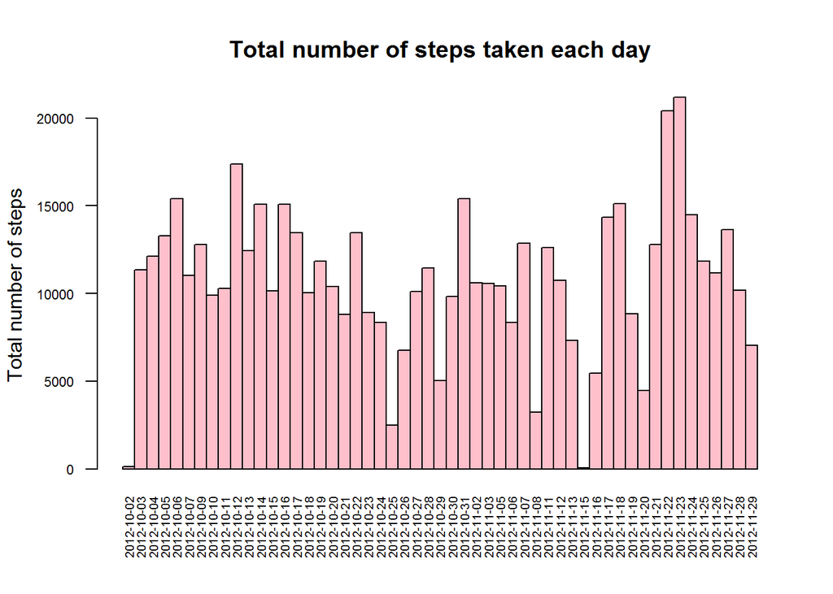

```r
with(dfStepsByDate, barplot(steps, names.arg = date, space = 0, las = 2, cex.names = 0.6, ylab = "Total number of steps", main = "Total number of steps taken each day", cex.axis = 0.7, col = "pink"))
```

3. Calculate and report the mean and median of the total number of steps taken per day

To achieve this, use the summary function, ensuring sufficient significant figures are used.

```r
summary(dfStepsByDate$steps, digits = 5)
```

```
##    Min. 1st Qu.  Median    Mean 3rd Qu.    Max.
##      41    8841   10765   10766   13294   21194
```

The mean is 10,766 steps and the median is 10,765 steps.

## What is the average daily activity pattern?

1. Make a time series plot (i.e. type = “l”) of the 5-minute interval (x-axis) and the average number of steps taken, averaged across all days (y-axis).

Create a dataframe containing the number of steps summarised by interval, and plot this:

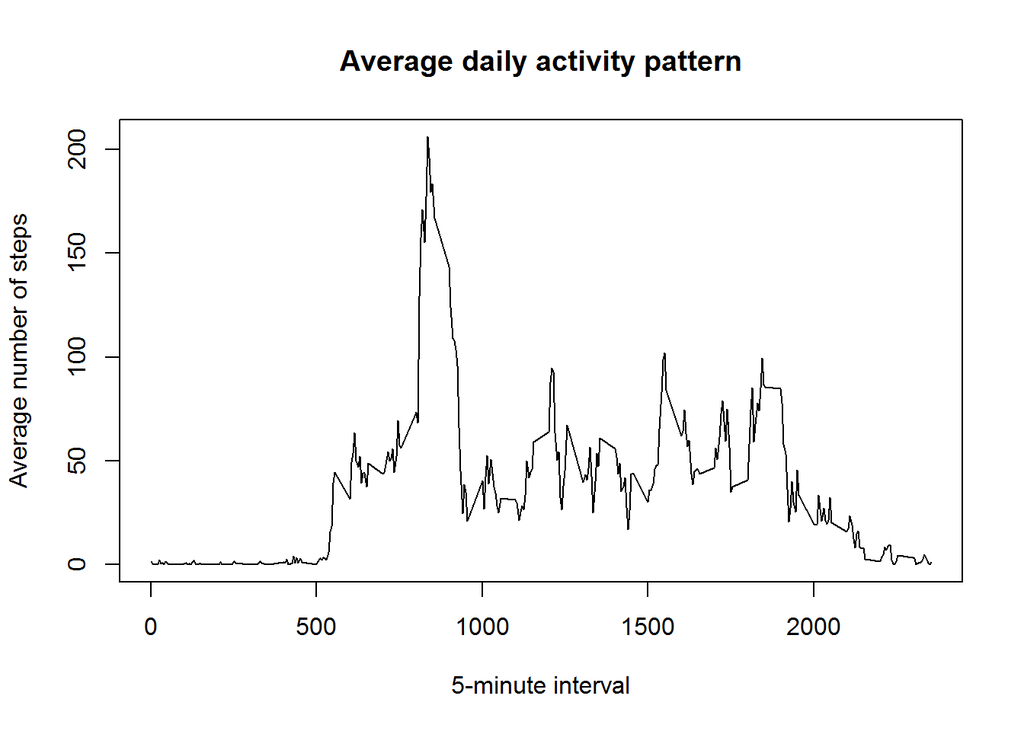

```r
dfStepsByInterval <- aggregate(steps ~ interval, data = dfRawData, mean, na.action = na.omit)
with(dfStepsByInterval, plot(interval, steps, type = "l", xlab = "5-minute interval", ylab = "Average number of steps", main = "Average daily activity pattern"))
```

2. Which 5-minute interval, on average across all the days in the dataset, contains the maximum number of steps?

This is determined by building a dataframe with the required data, sorting by the number of steps in reverse order, and choosing the top record:

```r
dfTotalStepsByInterval <- aggregate(steps ~ interval, data = dfRawData, sum, na.action = na.omit)
head(dfTotalStepsByInterval[order(-dfTotalStepsByInterval$steps),], 1)
```

```
##     interval steps
## 104      835 10927
```

The 5-minute interval containing the maximum number of steps is therefore 08:35.

## Imputing missing values

1. Calculate and report the total number of missing values in the dataset

To do this, use the apply function with is.na to check all columns for NAs:

```r
apply(dfRawData, 2, function(x) sum(is.na(x)))
```

```
##    steps     date interval
##     2304        0        0
```

It can be seen that 2,304 rows contain missing data.

2. Devise a strategy for filling in all of the missing values in the dataset.

The objective is to fill all missing values with the average number of steps for the relevant 5-minute interval. The strategy adopted was:

- Build a dataframe which is the result of a merge between the raw data and the summary of average steps by interval
- Copy the average value across to the steps column where there is a missing value

3.Create a new dataset that is equal to the original dataset but with the missing data filled in.

```r
dfMergedRawData <- setNames(merge(dfRawData, dfStepsByInterval, by = "interval"), c("interval","steps","date","averageSteps"))
dfMergedRawData$steps[is.na(dfMergedRawData$steps)] <- dfMergedRawData$averageSteps
```

```
## Warning in dfMergedRawData$steps[is.na(dfMergedRawData$steps)] <-
## dfMergedRawData$averageSteps: number of items to replace is not a multiple
## of replacement length
```

4. Make a histogram of the total number of steps taken each day and Calculate and report the mean and median total number of steps taken per day.

Again, use barplot to generate the required histogram:

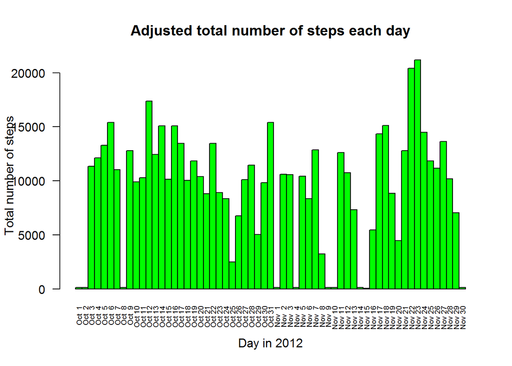

```r
dfAdjustedStepsByDate <- aggregate(steps ~ date, data = dfMergedRawData, sum)
with(dfAdjustedStepsByDate, barplot(steps, names.arg = format(as.Date(date), "%b %e"), space = 0, las = 2, cex.names = 0.6, xlab = "Day in 2012", ylab = "Total number of steps", main = "Adjusted total number of steps each day", col = "Green"))
```

The mean and median can be found as before:

```r
summary(dfAdjustedStepsByDate$steps, digits = 5)
```

```
##    Min. 1st Qu.  Median    Mean 3rd Qu.    Max.
##    41.0  6778.0 10395.0  9371.4 12811.0 21194.0
```

## Are there differences in activity patterns between weekdays and weekends?

1. Create a new factor variable in the dataset with two levels - “weekday” and “weekend” indicating whether a given date is a weekday or weekend day.

```r
dfMergedRawData$dayType <- as.factor(ifelse(weekdays(as.Date(dfMergedRawData$date)) %in% c("Saturday","Sunday"), "weekend", "weekday"))
```

2. Make a panel plot containing a time series plot of the 5-minute interval and the average number of steps taken, averaged across all weekday days or weekend days.

This plot is best done using the lattice library to allow easy stacking of the plots and hence easy comparison.

First, build the required dataframe:

```r
dfStepsByDayType <- aggregate(steps ~ interval + dayType, data = dfMergedRawData, mean)
```

Now plot the two day types stacked:

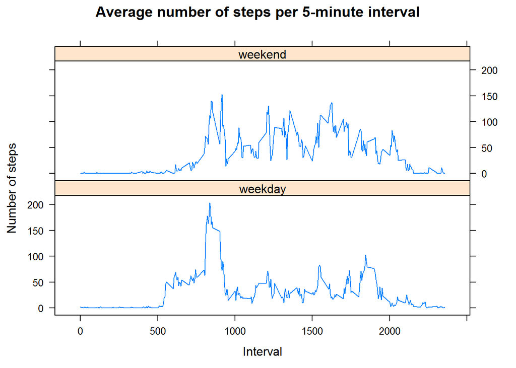

```r
attach(dfStepsByDayType)
xyplot(steps ~ interval|dayType, main = "Average number of steps per 5-minute interval", xlab = "Interval", ylab = "Number of steps", layout = c(1,2), type = "l")
```